# Predicting Crime Rate In Chicago Using Facebook Prophet

# Problem Statement

- The Chicago Crime dataset contains a summary of the reported crimes occurred in the City of Chicago from 2001 to 2017.
- Dataset has been obtained from the Chicago Police Department's CLEAR (Citizen Law Enforcement Analysis and Reporting) system.
- Dataset contains the following columns:
  - ID: Unique identifier for the record.
  - Case Number: The Chicago Police Department RD Number (Records Division Number), which is unique to the incident.
  - Date: Date when the incident occurred.
  - Block: address where the incident occurred
  - IUCR: The Illinois Unifrom Crime Reporting code.
  - Primary Type: The primary description of the IUCR code.
  - Description: The secondary description of the IUCR code, a subcategory of the primary description.
  - Location Description: Description of the location where the incident occurred.
  - Arrest: Indicates whether an arrest was made.
  - Domestic: Indicates whether the incident was domestic-related as defined by the Illinois Domestic Violence Act.
  - Beat: Indicates the beat where the incident occurred. A beat is the smallest police geographic area – each beat has a dedicated police beat car.
  - District: Indicates the police district where the incident occurred.
  - Ward: The ward (City Council district) where the incident occurred.
  - Community Area: Indicates the community area where the incident occurred. Chicago has 77 community areas.
  - FBI Code: Indicates the crime classification as outlined in the FBI's National Incident-Based Reporting System (NIBRS).
  - X Coordinate: The x coordinate of the location where the incident occurred in State Plane Illinois East NAD 1983 projection.
  - Y Coordinate: The y coordinate of the location where the incident occurred in State Plane Illinois East NAD 1983 projection.
  - Year: Year the incident occurred.
  - Updated On: Date and time the record was last updated.
  - Latitude: The latitude of the location where the incident occurred. This location is shifted from the actual location for partial redaction but falls on the same block.
  - Longitude: The longitude of the location where the incident occurred. This location is shifted from the actual location for partial redaction but falls on the same block.
  - Location: The location where the incident occurred in a format that allows for creation of maps and other geographic operations on this data portal. This location is shifted from the actual location for partial redaction but falls on the same block.
- Datasource: https://www.kaggle.com/currie32/crimes-in-chicago
- You must install fbprophet package as follows: pip install fbprophet
- If you encounter an error, try: conda install -c conda-forge fbprophet
- Prophet is open source software released by Facebook’s Core Data Science team.
- Prophet is a procedure for forecasting time series data based on an additive model where non-linear trends are fit with yearly, weekly, and daily seasonality, plus holiday effects.
- Prophet works best with time series that have strong seasonal effects and several seasons of historical data.
- For more information, please check this out: https://research.fb.com/prophet-forecasting-at-scale/ https://facebook.github.io/prophet/docs/quick_start.html#python-api

# Importing Data

```python
import pandas as pd
import numpy as np
import matplotlib.pyplot as plt
import random
import seaborn as sns
from fbprophet import Prophet
```

```python
# dataframes creation for both training and testing datasets
chicago_df_1 = pd.read_csv('Chicago_Crimes_2005_to_2007.csv', error_bad_lines=False)
chicago_df_2 = pd.read_csv('Chicago_Crimes_2008_to_2011.csv', error_bad_lines=False)
chicago_df_3 = pd.read_csv('Chicago_Crimes_2012_to_2017.csv', error_bad_lines=False)
```

```
b'Skipping line 533719: expected 23 fields, saw 24\n'
b'Skipping line 1149094: expected 23 fields, saw 41\n'
```

```python
chicago_df = pd.concat([chicago_df_1, chicago_df_2, chicago_df_3], ignore_index=False, axis=0)
```

# Exploring The Dataset

```python
# Let's view the head of the training dataset
chicago_df.head()
```

|  | Unnamed: 0 | ID | Case Number | Date | Block | IUCR | Primary Type | Description | Location Description | Arrest | ... | Ward | Community Area | FBI Code | X Coordinate | Y Coordinate | Year | Updated On | Latitude | Longitude | Location |
| --- | --- | --- | --- | --- | --- | --- | --- | --- | --- | --- | --- | --- | --- | --- | --- | --- | --- | --- | --- | --- | --- |
| 0 | 0 | 4673626 | HM274058 | 04/02/2006 01:00:00 PM | 055XX N MANGO AVE | 2825 | OTHER OFFENSE | HARASSMENT BY TELEPHONE | RESIDENCE | False | ... | 45.0 | 11.0 | 26 | 1136872.0 | 1936499.0 | 2006 | 04/15/2016 08:55:02 AM | 41.981913 | -87.771996 | (41.981912692, -87.771996382) |
| 1 | 1 | 4673627 | HM202199 | 02/26/2006 01:40:48 PM | 065XX S RHODES AVE | 2017 | NARCOTICS | MANU/DELIVER:CRACK | SIDEWALK | True | ... | 20.0 | 42.0 | 18 | 1181027.0 | 1861693.0 | 2006 | 04/15/2016 08:55:02 AM | 41.775733 | -87.611920 | (41.775732538, -87.611919814) |
| 2 | 2 | 4673628 | HM113861 | 01/08/2006 11:16:00 PM | 013XX E 69TH ST | 051A | ASSAULT | AGGRAVATED: HANDGUN | OTHER | False | ... | 5.0 | 69.0 | 04A | 1186023.0 | 1859609.0 | 2006 | 04/15/2016 08:55:02 AM | 41.769897 | -87.593671 | (41.769897392, -87.593670899) |
| 3 | 4 | 4673629 | HM274049 | 04/05/2006 06:45:00 PM | 061XX W NEWPORT AVE | 0460 | BATTERY | SIMPLE | RESIDENCE | False | ... | 38.0 | 17.0 | 08B | 1134772.0 | 1922299.0 | 2006 | 04/15/2016 08:55:02 AM | 41.942984 | -87.780057 | (41.942984005, -87.780056951) |
| 4 | 5 | 4673630 | HM187120 | 02/17/2006 09:03:14 PM | 037XX W 60TH ST | 1811 | NARCOTICS | POSS: CANNABIS 30GMS OR LESS | ALLEY | True | ... | 13.0 | 65.0 | 18 | 1152412.0 | 1864560.0 | 2006 | 04/15/2016 08:55:02 AM | 41.784211 | -87.716745 | (41.784210853, -87.71674491) |

5 rows × 23 columns

```python
# Let's view the last elements in the training dataset
chicago_df.tail(20)
```

|  | Unnamed: 0 | ID | Case Number | Date | Block | IUCR | Primary Type | Description | Location Description | Arrest | ... | Ward | Community Area | FBI Code | X Coordinate | Y Coordinate | Year | Updated On | Latitude | Longitude | Location |
| --- | --- | --- | --- | --- | --- | --- | --- | --- | --- | --- | --- | --- | --- | --- | --- | --- | --- | --- | --- | --- | --- |
| 1456694 | 6246478 | 10508650 | HZ250022 | 05/03/2016 05:00:00 PM | 078XX S MARSHFIELD AVE | 031A | ROBBERY | ARMED: HANDGUN | STREET | False | ... | 17.0 | 71.0 | 03 | 1166708.0 | 1852625.0 | 2016 | 05/10/2016 03:56:50 PM | 41.751166 | -87.664670 | (41.751166357, -87.664670209) |
| 1456695 | 6246521 | 10508653 | HZ250512 | 05/03/2016 11:58:00 PM | 026XX W LE MOYNE ST | 0520 | ASSAULT | AGGRAVATED:KNIFE/CUTTING INSTR | RESIDENTIAL YARD (FRONT/BACK) | True | ... | 26.0 | 24.0 | 04A | 1158381.0 | 1909870.0 | 2016 | 05/10/2016 03:56:50 PM | 41.908427 | -87.693623 | (41.908426978, -87.693622615) |
| 1456696 | 6247563 | 10508656 | HZ250476 | 05/03/2016 03:15:00 PM | 014XX N OGDEN AVE | 1720 | OFFENSE INVOLVING CHILDREN | CONTRIBUTE DELINQUENCY OF A CHILD | STREET | False | ... | 27.0 | 8.0 | 20 | 1171322.0 | 1909588.0 | 2016 | 05/10/2016 03:56:50 PM | 41.907378 | -87.646092 | (41.907378476, -87.64609233) |
| 1456697 | 6247798 | 10508658 | HZ250506 | 05/03/2016 11:50:00 PM | 018XX S KEDZIE AVE | 4625 | OTHER OFFENSE | PAROLE VIOLATION | STREET | True | ... | 24.0 | 29.0 | 26 | 1155317.0 | 1890928.0 | 2016 | 05/10/2016 03:56:50 PM | 41.856510 | -87.705387 | (41.856510401, -87.705387422) |
| 1456698 | 6248016 | 10508659 | HZ250499 | 05/03/2016 11:38:00 PM | 038XX S PRINCETON AVE | 0460 | BATTERY | SIMPLE | CHA PARKING LOT/GROUNDS | False | ... | 3.0 | 34.0 | 08B | 1174922.0 | 1879297.0 | 2016 | 05/10/2016 03:56:50 PM | 41.824178 | -87.633775 | (41.82417802, -87.6337748) |
| 1456699 | 6248192 | 10508661 | HZ250344 | 05/03/2016 08:44:00 PM | 070XX S WABASH AVE | 041A | BATTERY | AGGRAVATED: HANDGUN | STREET | False | ... | 6.0 | 69.0 | 04B | 1177941.0 | 1858411.0 | 2016 | 05/10/2016 03:56:50 PM | 41.766797 | -87.623332 | (41.766796861, -87.623332025) |
| 1456700 | 6248278 | 10508662 | HZ250477 | 05/03/2016 08:00:00 AM | 057XX S MICHIGAN AVE | 5001 | OTHER OFFENSE | OTHER CRIME INVOLVING PROPERTY | APARTMENT | False | ... | 20.0 | 40.0 | 26 | 1178135.0 | 1867058.0 | 2016 | 05/10/2016 03:56:50 PM | 41.790521 | -87.622359 | (41.790520722, -87.622358898) |
| 1456701 | 6248713 | 10508663 | HZ250466 | 05/03/2016 10:10:00 PM | 033XX W MARQUETTE RD | 1563 | SEX OFFENSE | CRIMINAL SEXUAL ABUSE | APARTMENT | False | ... | 15.0 | 66.0 | 17 | 1155359.0 | 1859995.0 | 2016 | 05/10/2016 03:56:50 PM | 41.771625 | -87.706062 | (41.771625308, -87.706062047) |
| 1456702 | 6248779 | 10508664 | HZ250486 | 05/03/2016 11:35:00 PM | 083XX S CARPENTER ST | 0560 | ASSAULT | SIMPLE | RESIDENCE | True | ... | 21.0 | 71.0 | 08A | 1170770.0 | 1849485.0 | 2016 | 05/10/2016 03:56:50 PM | 41.742462 | -87.649876 | (41.742462184, -87.649876395) |
| 1456703 | 6248999 | 10508665 | HZ250448 | 05/03/2016 10:15:00 PM | 095XX S LOOMIS ST | 1310 | CRIMINAL DAMAGE | TO PROPERTY | RESIDENCE | False | ... | 21.0 | 73.0 | 14 | 1168707.0 | 1841343.0 | 2016 | 05/10/2016 03:56:50 PM | 41.720164 | -87.657669 | (41.720164061, -87.657669427) |
| 1456704 | 6249417 | 10508666 | HZ250497 | 05/03/2016 11:30:00 PM | 053XX S PULASKI RD | 0320 | ROBBERY | STRONGARM - NO WEAPON | SIDEWALK | False | ... | 23.0 | 62.0 | 03 | 1150606.0 | 1868988.0 | 2016 | 05/10/2016 03:56:50 PM | 41.796397 | -87.723251 | (41.79639731, -87.723251281) |
| 1456705 | 6249592 | 10508671 | HZ250526 | 05/03/2016 11:50:00 PM | 036XX E 106TH ST | 502P | OTHER OFFENSE | FALSE/STOLEN/ALTERED TRP | ALLEY | True | ... | 10.0 | 52.0 | 26 | 1202327.0 | 1835278.0 | 2016 | 05/10/2016 03:56:50 PM | 41.702731 | -87.534736 | (41.702731182, -87.534736413) |
| 1456706 | 6249615 | 10508672 | HZ250441 | 05/03/2016 10:25:00 PM | 071XX S MOZART ST | 0460 | BATTERY | SIMPLE | SIDEWALK | True | ... | 18.0 | 66.0 | 08B | 1158610.0 | 1857066.0 | 2016 | 05/10/2016 03:56:50 PM | 41.763522 | -87.694225 | (41.763522012, -87.69422464) |
| 1456707 | 6249936 | 10508675 | HZ250502 | 05/03/2016 11:00:00 PM | 085XX S MAY ST | 0320 | ROBBERY | STRONGARM - NO WEAPON | SIDEWALK | False | ... | 21.0 | 71.0 | 03 | 1170146.0 | 1848113.0 | 2016 | 05/10/2016 03:56:50 PM | 41.738711 | -87.652203 | (41.738710803, -87.652202523) |
| 1456708 | 6250154 | 10508678 | HZ250481 | 05/03/2016 11:28:00 PM | 088XX S LAFLIN ST | 041A | BATTERY | AGGRAVATED: HANDGUN | STREET | False | ... | 21.0 | 71.0 | 04B | 1167880.0 | 1846134.0 | 2016 | 05/10/2016 03:56:50 PM | 41.733329 | -87.660561 | (41.733329054, -87.660561367) |
| 1456709 | 6250330 | 10508679 | HZ250507 | 05/03/2016 11:33:00 PM | 026XX W 23RD PL | 0486 | BATTERY | DOMESTIC BATTERY SIMPLE | APARTMENT | True | ... | 28.0 | 30.0 | 08B | 1159105.0 | 1888300.0 | 2016 | 05/10/2016 03:56:50 PM | 41.849222 | -87.691556 | (41.849222028, -87.69155551) |
| 1456710 | 6251089 | 10508680 | HZ250491 | 05/03/2016 11:30:00 PM | 073XX S HARVARD AVE | 1310 | CRIMINAL DAMAGE | TO PROPERTY | APARTMENT | True | ... | 17.0 | 69.0 | 14 | 1175230.0 | 1856183.0 | 2016 | 05/10/2016 03:56:50 PM | 41.760744 | -87.633335 | (41.760743949, -87.63333531) |
| 1456711 | 6251349 | 10508681 | HZ250479 | 05/03/2016 12:15:00 AM | 024XX W 63RD ST | 041A | BATTERY | AGGRAVATED: HANDGUN | SIDEWALK | False | ... | 15.0 | 66.0 | 04B | 1161027.0 | 1862810.0 | 2016 | 05/10/2016 03:56:50 PM | 41.779235 | -87.685207 | (41.779234743, -87.685207125) |
| 1456712 | 6253257 | 10508690 | HZ250370 | 05/03/2016 09:07:00 PM | 082XX S EXCHANGE AVE | 0486 | BATTERY | DOMESTIC BATTERY SIMPLE | SIDEWALK | False | ... | 7.0 | 46.0 | 08B | 1197261.0 | 1850727.0 | 2016 | 05/10/2016 03:56:50 PM | 41.745252 | -87.552773 | (41.745251975, -87.552773464) |
| 1456713 | 6253474 | 10508692 | HZ250517 | 05/03/2016 11:38:00 PM | 001XX E 75TH ST | 5007 | OTHER OFFENSE | OTHER WEAPONS VIOLATION | PARKING LOT/GARAGE(NON.RESID.) | True | ... | 6.0 | 69.0 | 26 | 1178696.0 | 1855324.0 | 2016 | 05/10/2016 03:56:50 PM | 41.758309 | -87.620658 | (41.75830866, -87.620658418) |

20 rows × 23 columns

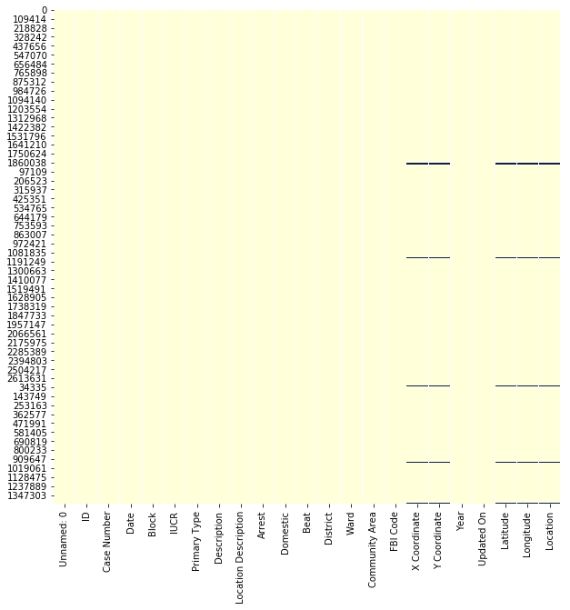

```python
# Let's see how many null elements are contained in the data
plt.figure(figsize=(10,10))
sns.heatmap(chicago_df.isnull(), cbar = False, cmap = 'YlGnBu')
```

```python
# ID Case Number Date Block IUCR Primary Type Description Location Description Arrest Domestic Beat District Ward Community Area FBI Code X Coordinate Y Coordinate Year Updated On Latitude Longitude Location
chicago_df.drop(['Unnamed: 0', 'Case Number', 'Case Number', 'IUCR', 'X Coordinate', 'Y Coordinate','Updated On','Year', 'FBI Code', 'Beat','Ward','Community Area', 'Location', 'District', 'Latitude' , 'Longitude'], inplace=True, axis=1)
```

```python
chicago_df
```

|  | ID | Date | Block | Primary Type | Description | Location Description | Arrest | Domestic |
| --- | --- | --- | --- | --- | --- | --- | --- | --- |
| 0 | 4673626 | 04/02/2006 01:00:00 PM | 055XX N MANGO AVE | OTHER OFFENSE | HARASSMENT BY TELEPHONE | RESIDENCE | False | False |
| 1 | 4673627 | 02/26/2006 01:40:48 PM | 065XX S RHODES AVE | NARCOTICS | MANU/DELIVER:CRACK | SIDEWALK | True | False |
| 2 | 4673628 | 01/08/2006 11:16:00 PM | 013XX E 69TH ST | ASSAULT | AGGRAVATED: HANDGUN | OTHER | False | False |
| 3 | 4673629 | 04/05/2006 06:45:00 PM | 061XX W NEWPORT AVE | BATTERY | SIMPLE | RESIDENCE | False | False |
| 4 | 4673630 | 02/17/2006 09:03:14 PM | 037XX W 60TH ST | NARCOTICS | POSS: CANNABIS 30GMS OR LESS | ALLEY | True | False |
| 5 | 4673631 | 03/30/2006 10:30:00 PM | 014XX W 73RD PL | ASSAULT | SIMPLE | APARTMENT | True | False |
| 6 | 4673632 | 04/05/2006 12:10:00 PM | 050XX N LARAMIE AVE | BATTERY | SIMPLE | SCHOOL, PUBLIC, BUILDING | True | False |
| 7 | 4673633 | 04/05/2006 03:00:00 PM | 067XX S ROCKWELL ST | THEFT | $500 AND UNDER | STREET | False | False |
| 8 | 4673634 | 04/05/2006 09:30:00 PM | 019XX W CHICAGO AVE | ASSAULT | SIMPLE | PARKING LOT/GARAGE(NON.RESID.) | False | False |
| 9 | 4673635 | 04/03/2006 03:00:00 AM | 063XX S EBERHART AVE | BATTERY | DOMESTIC BATTERY SIMPLE | SIDEWALK | False | True |
| 10 | 4673637 | 04/06/2006 11:15:00 AM | 0000X N LA SALLE ST | THEFT | OVER $500 | STREET | False | False |
| 11 | 4673639 | 04/04/2006 08:15:00 PM | 029XX S FEDERAL ST | CRIMINAL TRESPASS | TO STATE SUP LAND | CHA HALLWAY/STAIRWELL/ELEVATOR | True | False |
| 12 | 4673640 | 04/06/2006 11:30:00 AM | 017XX E 86TH PL | MOTOR VEHICLE THEFT | THEFT/RECOVERY: TRUCK,BUS,MHOME | STREET | False | False |
| 13 | 4673642 | 02/26/2006 02:47:21 PM | 002XX S LEAMINGTON AVE | NARCOTICS | POSS: CANNABIS 30GMS OR LESS | SIDEWALK | True | False |
| 14 | 4673643 | 04/03/2006 08:09:00 PM | 073XX S WOODLAWN AVE | BATTERY | AGGRAVATED:KNIFE/CUTTING INSTR | SIDEWALK | False | False |
| 15 | 4673644 | 02/17/2006 09:26:33 PM | 052XX S FAIRFIELD AVE | NARCOTICS | POSS: CANNABIS 30GMS OR LESS | STREET | True | False |
| 16 | 4673645 | 04/05/2006 08:00:00 AM | 024XX W HARRISON ST | MOTOR VEHICLE THEFT | THEFT/RECOVERY: TRUCK,BUS,MHOME | STREET | False | False |
| 17 | 4673646 | 03/31/2006 08:20:00 AM | 067XX S PERRY AVE | BATTERY | DOMESTIC BATTERY SIMPLE | RESIDENCE | False | True |
| 18 | 4673648 | 04/05/2006 01:30:00 PM | 046XX N MILWAUKEE AVE | CRIMINAL TRESPASS | TO LAND | PARK PROPERTY | True | False |
| 19 | 4673649 | 03/31/2006 05:00:00 AM | 062XX S RACINE AVE | THEFT | OVER $500 | SCHOOL, PUBLIC, GROUNDS | False | False |
| 20 | 4674087 | 03/28/2006 10:00:00 PM | 036XX N TRIPP AVE | THEFT | FROM BUILDING | RESIDENCE | False | False |
| 21 | 4673651 | 02/17/2006 09:49:21 PM | 025XX W 63RD ST | NARCOTICS | POSS: CANNABIS 30GMS OR LESS | STREET | True | False |
| 22 | 4673652 | 04/05/2006 06:18:00 PM | 064XX S EVANS AVE | BATTERY | AGG: HANDS/FIST/FEET SERIOUS INJURY | STREET | False | False |
| 23 | 4673653 | 04/06/2006 09:45:00 AM | 003XX E SUPERIOR ST | THEFT | FROM BUILDING | COMMERCIAL / BUSINESS OFFICE | False | False |
| 24 | 4673654 | 03/31/2006 09:13:54 AM | 067XX S CARPENTER ST | BATTERY | DOMESTIC BATTERY SIMPLE | STREET | True | True |
| 25 | 4673655 | 04/05/2006 10:30:00 PM | 086XX W CATHERINE AVE | ASSAULT | SIMPLE | RESIDENCE | False | False |
| 26 | 4673656 | 04/05/2006 10:10:00 PM | 006XX E 75TH ST | ROBBERY | STRONGARM - NO WEAPON | OTHER | False | False |
| 27 | 4673657 | 03/31/2006 10:00:00 AM | 018XX W 69TH ST | OTHER OFFENSE | FALSE/STOLEN/ALTERED TRP | STREET | True | False |
| 28 | 4673658 | 02/17/2006 10:07:09 PM | 013XX W 99TH ST | NARCOTICS | POSS: CANNABIS 30GMS OR LESS | STREET | True | False |
| 29 | 4673659 | 04/05/2006 05:00:00 PM | 013XX N MONITOR AVE | MOTOR VEHICLE THEFT | AUTOMOBILE | STREET | False | False |
| ... | ... | ... | ... | ... | ... | ... | ... | ... |
| 1456684 | 10508639 | 05/03/2016 10:32:00 PM | 037XX S HERMITAGE AVE | ASSAULT | AGGRAVATED: HANDGUN | RESIDENCE | False | False |
| 1456685 | 10508640 | 05/03/2016 10:07:00 PM | 035XX W ROOSEVELT RD | NARCOTICS | POSS: CANNABIS 30GMS OR LESS | STREET | True | False |
| 1456686 | 10508641 | 05/03/2016 10:31:00 PM | 066XX S WOLCOTT AVE | WEAPONS VIOLATION | UNLAWFUL POSS OF HANDGUN | RESIDENCE | False | False |
| 1456687 | 10508642 | 05/03/2016 10:45:00 PM | 027XX W FLOURNOY ST | ASSAULT | AGGRAVATED: HANDGUN | APARTMENT | False | True |
| 1456688 | 10508643 | 05/03/2016 09:00:00 PM | 075XX S PARNELL AVE | ASSAULT | SIMPLE | RESIDENCE | False | True |
| 1456689 | 10508644 | 05/03/2016 07:13:00 PM | 076XX S HALSTED ST | BATTERY | SIMPLE | STREET | False | False |
| 1456690 | 10508646 | 05/03/2016 07:45:00 PM | 080XX S VERNON AVE | BATTERY | SIMPLE | APARTMENT | False | False |
| 1456691 | 10508647 | 05/03/2016 08:56:00 PM | 063XX S GREENWOOD AVE | BATTERY | SIMPLE | STREET | False | False |
| 1456692 | 10508648 | 05/03/2016 10:10:00 PM | 073XX S MERRILL AVE | ASSAULT | AGGRAVATED:KNIFE/CUTTING INSTR | APARTMENT | True | True |
| 1456693 | 10508649 | 05/03/2016 10:15:00 PM | 041XX W CERMAK RD | OTHER OFFENSE | VIOLATE ORDER OF PROTECTION | OTHER | False | False |
| 1456694 | 10508650 | 05/03/2016 05:00:00 PM | 078XX S MARSHFIELD AVE | ROBBERY | ARMED: HANDGUN | STREET | False | False |
| 1456695 | 10508653 | 05/03/2016 11:58:00 PM | 026XX W LE MOYNE ST | ASSAULT | AGGRAVATED:KNIFE/CUTTING INSTR | RESIDENTIAL YARD (FRONT/BACK) | True | False |
| 1456696 | 10508656 | 05/03/2016 03:15:00 PM | 014XX N OGDEN AVE | OFFENSE INVOLVING CHILDREN | CONTRIBUTE DELINQUENCY OF A CHILD | STREET | False | True |
| 1456697 | 10508658 | 05/03/2016 11:50:00 PM | 018XX S KEDZIE AVE | OTHER OFFENSE | PAROLE VIOLATION | STREET | True | False |
| 1456698 | 10508659 | 05/03/2016 11:38:00 PM | 038XX S PRINCETON AVE | BATTERY | SIMPLE | CHA PARKING LOT/GROUNDS | False | False |
| 1456699 | 10508661 | 05/03/2016 08:44:00 PM | 070XX S WABASH AVE | BATTERY | AGGRAVATED: HANDGUN | STREET | False | False |
| 1456700 | 10508662 | 05/03/2016 08:00:00 AM | 057XX S MICHIGAN AVE | OTHER OFFENSE | OTHER CRIME INVOLVING PROPERTY | APARTMENT | False | False |
| 1456701 | 10508663 | 05/03/2016 10:10:00 PM | 033XX W MARQUETTE RD | SEX OFFENSE | CRIMINAL SEXUAL ABUSE | APARTMENT | False | False |
| 1456702 | 10508664 | 05/03/2016 11:35:00 PM | 083XX S CARPENTER ST | ASSAULT | SIMPLE | RESIDENCE | True | True |
| 1456703 | 10508665 | 05/03/2016 10:15:00 PM | 095XX S LOOMIS ST | CRIMINAL DAMAGE | TO PROPERTY | RESIDENCE | False | True |
| 1456704 | 10508666 | 05/03/2016 11:30:00 PM | 053XX S PULASKI RD | ROBBERY | STRONGARM - NO WEAPON | SIDEWALK | False | False |
| 1456705 | 10508671 | 05/03/2016 11:50:00 PM | 036XX E 106TH ST | OTHER OFFENSE | FALSE/STOLEN/ALTERED TRP | ALLEY | True | False |
| 1456706 | 10508672 | 05/03/2016 10:25:00 PM | 071XX S MOZART ST | BATTERY | SIMPLE | SIDEWALK | True | False |
| 1456707 | 10508675 | 05/03/2016 11:00:00 PM | 085XX S MAY ST | ROBBERY | STRONGARM - NO WEAPON | SIDEWALK | False | False |
| 1456708 | 10508678 | 05/03/2016 11:28:00 PM | 088XX S LAFLIN ST | BATTERY | AGGRAVATED: HANDGUN | STREET | False | False |
| 1456709 | 10508679 | 05/03/2016 11:33:00 PM | 026XX W 23RD PL | BATTERY | DOMESTIC BATTERY SIMPLE | APARTMENT | True | True |
| 1456710 | 10508680 | 05/03/2016 11:30:00 PM | 073XX S HARVARD AVE | CRIMINAL DAMAGE | TO PROPERTY | APARTMENT | True | True |
| 1456711 | 10508681 | 05/03/2016 12:15:00 AM | 024XX W 63RD ST | BATTERY | AGGRAVATED: HANDGUN | SIDEWALK | False | False |
| 1456712 | 10508690 | 05/03/2016 09:07:00 PM | 082XX S EXCHANGE AVE | BATTERY | DOMESTIC BATTERY SIMPLE | SIDEWALK | False | True |
| 1456713 | 10508692 | 05/03/2016 11:38:00 PM | 001XX E 75TH ST | OTHER OFFENSE | OTHER WEAPONS VIOLATION | PARKING LOT/GARAGE(NON.RESID.) | True | False |

6017767 rows × 8 columns

```python
# Assembling a datetime by rearranging the dataframe column "Date".

chicago_df.Date = pd.to_datetime(chicago_df.Date, format='%m/%d/%Y %I:%M:%S %p')
```

```python
chicago_df
```

|  | ID | Date | Block | Primary Type | Description | Location Description | Arrest | Domestic |
| --- | --- | --- | --- | --- | --- | --- | --- | --- |
| 0 | 4673626 | 2006-04-02 13:00:00 | 055XX N MANGO AVE | OTHER OFFENSE | HARASSMENT BY TELEPHONE | RESIDENCE | False | False |
| 1 | 4673627 | 2006-02-26 13:40:48 | 065XX S RHODES AVE | NARCOTICS | MANU/DELIVER:CRACK | SIDEWALK | True | False |
| 2 | 4673628 | 2006-01-08 23:16:00 | 013XX E 69TH ST | ASSAULT | AGGRAVATED: HANDGUN | OTHER | False | False |
| 3 | 4673629 | 2006-04-05 18:45:00 | 061XX W NEWPORT AVE | BATTERY | SIMPLE | RESIDENCE | False | False |
| 4 | 4673630 | 2006-02-17 21:03:14 | 037XX W 60TH ST | NARCOTICS | POSS: CANNABIS 30GMS OR LESS | ALLEY | True | False |
| 5 | 4673631 | 2006-03-30 22:30:00 | 014XX W 73RD PL | ASSAULT | SIMPLE | APARTMENT | True | False |
| 6 | 4673632 | 2006-04-05 12:10:00 | 050XX N LARAMIE AVE | BATTERY | SIMPLE | SCHOOL, PUBLIC, BUILDING | True | False |
| 7 | 4673633 | 2006-04-05 15:00:00 | 067XX S ROCKWELL ST | THEFT | $500 AND UNDER | STREET | False | False |
| 8 | 4673634 | 2006-04-05 21:30:00 | 019XX W CHICAGO AVE | ASSAULT | SIMPLE | PARKING LOT/GARAGE(NON.RESID.) | False | False |
| 9 | 4673635 | 2006-04-03 03:00:00 | 063XX S EBERHART AVE | BATTERY | DOMESTIC BATTERY SIMPLE | SIDEWALK | False | True |
| 10 | 4673637 | 2006-04-06 11:15:00 | 0000X N LA SALLE ST | THEFT | OVER $500 | STREET | False | False |
| 11 | 4673639 | 2006-04-04 20:15:00 | 029XX S FEDERAL ST | CRIMINAL TRESPASS | TO STATE SUP LAND | CHA HALLWAY/STAIRWELL/ELEVATOR | True | False |
| 12 | 4673640 | 2006-04-06 11:30:00 | 017XX E 86TH PL | MOTOR VEHICLE THEFT | THEFT/RECOVERY: TRUCK,BUS,MHOME | STREET | False | False |
| 13 | 4673642 | 2006-02-26 14:47:21 | 002XX S LEAMINGTON AVE | NARCOTICS | POSS: CANNABIS 30GMS OR LESS | SIDEWALK | True | False |
| 14 | 4673643 | 2006-04-03 20:09:00 | 073XX S WOODLAWN AVE | BATTERY | AGGRAVATED:KNIFE/CUTTING INSTR | SIDEWALK | False | False |
| 15 | 4673644 | 2006-02-17 21:26:33 | 052XX S FAIRFIELD AVE | NARCOTICS | POSS: CANNABIS 30GMS OR LESS | STREET | True | False |
| 16 | 4673645 | 2006-04-05 08:00:00 | 024XX W HARRISON ST | MOTOR VEHICLE THEFT | THEFT/RECOVERY: TRUCK,BUS,MHOME | STREET | False | False |
| 17 | 4673646 | 2006-03-31 08:20:00 | 067XX S PERRY AVE | BATTERY | DOMESTIC BATTERY SIMPLE | RESIDENCE | False | True |
| 18 | 4673648 | 2006-04-05 13:30:00 | 046XX N MILWAUKEE AVE | CRIMINAL TRESPASS | TO LAND | PARK PROPERTY | True | False |
| 19 | 4673649 | 2006-03-31 05:00:00 | 062XX S RACINE AVE | THEFT | OVER $500 | SCHOOL, PUBLIC, GROUNDS | False | False |
| 20 | 4674087 | 2006-03-28 22:00:00 | 036XX N TRIPP AVE | THEFT | FROM BUILDING | RESIDENCE | False | False |
| 21 | 4673651 | 2006-02-17 21:49:21 | 025XX W 63RD ST | NARCOTICS | POSS: CANNABIS 30GMS OR LESS | STREET | True | False |
| 22 | 4673652 | 2006-04-05 18:18:00 | 064XX S EVANS AVE | BATTERY | AGG: HANDS/FIST/FEET SERIOUS INJURY | STREET | False | False |
| 23 | 4673653 | 2006-04-06 09:45:00 | 003XX E SUPERIOR ST | THEFT | FROM BUILDING | COMMERCIAL / BUSINESS OFFICE | False | False |
| 24 | 4673654 | 2006-03-31 09:13:54 | 067XX S CARPENTER ST | BATTERY | DOMESTIC BATTERY SIMPLE | STREET | True | True |
| 25 | 4673655 | 2006-04-05 22:30:00 | 086XX W CATHERINE AVE | ASSAULT | SIMPLE | RESIDENCE | False | False |
| 26 | 4673656 | 2006-04-05 22:10:00 | 006XX E 75TH ST | ROBBERY | STRONGARM - NO WEAPON | OTHER | False | False |
| 27 | 4673657 | 2006-03-31 10:00:00 | 018XX W 69TH ST | OTHER OFFENSE | FALSE/STOLEN/ALTERED TRP | STREET | True | False |
| 28 | 4673658 | 2006-02-17 22:07:09 | 013XX W 99TH ST | NARCOTICS | POSS: CANNABIS 30GMS OR LESS | STREET | True | False |
| 29 | 4673659 | 2006-04-05 17:00:00 | 013XX N MONITOR AVE | MOTOR VEHICLE THEFT | AUTOMOBILE | STREET | False | False |
| ... | ... | ... | ... | ... | ... | ... | ... | ... |
| 1456684 | 10508639 | 2016-05-03 22:32:00 | 037XX S HERMITAGE AVE | ASSAULT | AGGRAVATED: HANDGUN | RESIDENCE | False | False |
| 1456685 | 10508640 | 2016-05-03 22:07:00 | 035XX W ROOSEVELT RD | NARCOTICS | POSS: CANNABIS 30GMS OR LESS | STREET | True | False |
| 1456686 | 10508641 | 2016-05-03 22:31:00 | 066XX S WOLCOTT AVE | WEAPONS VIOLATION | UNLAWFUL POSS OF HANDGUN | RESIDENCE | False | False |
| 1456687 | 10508642 | 2016-05-03 22:45:00 | 027XX W FLOURNOY ST | ASSAULT | AGGRAVATED: HANDGUN | APARTMENT | False | True |
| 1456688 | 10508643 | 2016-05-03 21:00:00 | 075XX S PARNELL AVE | ASSAULT | SIMPLE | RESIDENCE | False | True |
| 1456689 | 10508644 | 2016-05-03 19:13:00 | 076XX S HALSTED ST | BATTERY | SIMPLE | STREET | False | False |
| 1456690 | 10508646 | 2016-05-03 19:45:00 | 080XX S VERNON AVE | BATTERY | SIMPLE | APARTMENT | False | False |
| 1456691 | 10508647 | 2016-05-03 20:56:00 | 063XX S GREENWOOD AVE | BATTERY | SIMPLE | STREET | False | False |
| 1456692 | 10508648 | 2016-05-03 22:10:00 | 073XX S MERRILL AVE | ASSAULT | AGGRAVATED:KNIFE/CUTTING INSTR | APARTMENT | True | True |
| 1456693 | 10508649 | 2016-05-03 22:15:00 | 041XX W CERMAK RD | OTHER OFFENSE | VIOLATE ORDER OF PROTECTION | OTHER | False | False |
| 1456694 | 10508650 | 2016-05-03 17:00:00 | 078XX S MARSHFIELD AVE | ROBBERY | ARMED: HANDGUN | STREET | False | False |
| 1456695 | 10508653 | 2016-05-03 23:58:00 | 026XX W LE MOYNE ST | ASSAULT | AGGRAVATED:KNIFE/CUTTING INSTR | RESIDENTIAL YARD (FRONT/BACK) | True | False |
| 1456696 | 10508656 | 2016-05-03 15:15:00 | 014XX N OGDEN AVE | OFFENSE INVOLVING CHILDREN | CONTRIBUTE DELINQUENCY OF A CHILD | STREET | False | True |
| 1456697 | 10508658 | 2016-05-03 23:50:00 | 018XX S KEDZIE AVE | OTHER OFFENSE | PAROLE VIOLATION | STREET | True | False |
| 1456698 | 10508659 | 2016-05-03 23:38:00 | 038XX S PRINCETON AVE | BATTERY | SIMPLE | CHA PARKING LOT/GROUNDS | False | False |
| 1456699 | 10508661 | 2016-05-03 20:44:00 | 070XX S WABASH AVE | BATTERY | AGGRAVATED: HANDGUN | STREET | False | False |
| 1456700 | 10508662 | 2016-05-03 08:00:00 | 057XX S MICHIGAN AVE | OTHER OFFENSE | OTHER CRIME INVOLVING PROPERTY | APARTMENT | False | False |
| 1456701 | 10508663 | 2016-05-03 22:10:00 | 033XX W MARQUETTE RD | SEX OFFENSE | CRIMINAL SEXUAL ABUSE | APARTMENT | False | False |
| 1456702 | 10508664 | 2016-05-03 23:35:00 | 083XX S CARPENTER ST | ASSAULT | SIMPLE | RESIDENCE | True | True |
| 1456703 | 10508665 | 2016-05-03 22:15:00 | 095XX S LOOMIS ST | CRIMINAL DAMAGE | TO PROPERTY | RESIDENCE | False | True |
| 1456704 | 10508666 | 2016-05-03 23:30:00 | 053XX S PULASKI RD | ROBBERY | STRONGARM - NO WEAPON | SIDEWALK | False | False |
| 1456705 | 10508671 | 2016-05-03 23:50:00 | 036XX E 106TH ST | OTHER OFFENSE | FALSE/STOLEN/ALTERED TRP | ALLEY | True | False |
| 1456706 | 10508672 | 2016-05-03 22:25:00 | 071XX S MOZART ST | BATTERY | SIMPLE | SIDEWALK | True | False |
| 1456707 | 10508675 | 2016-05-03 23:00:00 | 085XX S MAY ST | ROBBERY | STRONGARM - NO WEAPON | SIDEWALK | False | False |
| 1456708 | 10508678 | 2016-05-03 23:28:00 | 088XX S LAFLIN ST | BATTERY | AGGRAVATED: HANDGUN | STREET | False | False |
| 1456709 | 10508679 | 2016-05-03 23:33:00 | 026XX W 23RD PL | BATTERY | DOMESTIC BATTERY SIMPLE | APARTMENT | True | True |
| 1456710 | 10508680 | 2016-05-03 23:30:00 | 073XX S HARVARD AVE | CRIMINAL DAMAGE | TO PROPERTY | APARTMENT | True | True |
| 1456711 | 10508681 | 2016-05-03 00:15:00 | 024XX W 63RD ST | BATTERY | AGGRAVATED: HANDGUN | SIDEWALK | False | False |
| 1456712 | 10508690 | 2016-05-03 21:07:00 | 082XX S EXCHANGE AVE | BATTERY | DOMESTIC BATTERY SIMPLE | SIDEWALK | False | True |
| 1456713 | 10508692 | 2016-05-03 23:38:00 | 001XX E 75TH ST | OTHER OFFENSE | OTHER WEAPONS VIOLATION | PARKING LOT/GARAGE(NON.RESID.) | True | False |

6017767 rows × 8 columns

```python
# setting the index to be the date
chicago_df.index = pd.DatetimeIndex(chicago_df.Date)
```

```python
chicago_df
```

| Date | ID | Date | Block | Primary Type | Description | Location Description | Arrest | Domestic |
| --- | --- | --- | --- | --- | --- | --- | --- | --- |
| 2006-04-02 13:00:00 | 4673626 | 2006-04-02 13:00:00 | 055XX N MANGO AVE | OTHER OFFENSE | HARASSMENT BY TELEPHONE | RESIDENCE | False | False |
| 2006-02-26 13:40:48 | 4673627 | 2006-02-26 13:40:48 | 065XX S RHODES AVE | NARCOTICS | MANU/DELIVER:CRACK | SIDEWALK | True | False |
| 2006-01-08 23:16:00 | 4673628 | 2006-01-08 23:16:00 | 013XX E 69TH ST | ASSAULT | AGGRAVATED: HANDGUN | OTHER | False | False |
| 2006-04-05 18:45:00 | 4673629 | 2006-04-05 18:45:00 | 061XX W NEWPORT AVE | BATTERY | SIMPLE | RESIDENCE | False | False |
| 2006-02-17 21:03:14 | 4673630 | 2006-02-17 21:03:14 | 037XX W 60TH ST | NARCOTICS | POSS: CANNABIS 30GMS OR LESS | ALLEY | True | False |
| 2006-03-30 22:30:00 | 4673631 | 2006-03-30 22:30:00 | 014XX W 73RD PL | ASSAULT | SIMPLE | APARTMENT | True | False |
| 2006-04-05 12:10:00 | 4673632 | 2006-04-05 12:10:00 | 050XX N LARAMIE AVE | BATTERY | SIMPLE | SCHOOL, PUBLIC, BUILDING | True | False |
| 2006-04-05 15:00:00 | 4673633 | 2006-04-05 15:00:00 | 067XX S ROCKWELL ST | THEFT | $500 AND UNDER | STREET | False | False |
| 2006-04-05 21:30:00 | 4673634 | 2006-04-05 21:30:00 | 019XX W CHICAGO AVE | ASSAULT | SIMPLE | PARKING LOT/GARAGE(NON.RESID.) | False | False |
| 2006-04-03 03:00:00 | 4673635 | 2006-04-03 03:00:00 | 063XX S EBERHART AVE | BATTERY | DOMESTIC BATTERY SIMPLE | SIDEWALK | False | True |
| 2006-04-06 11:15:00 | 4673637 | 2006-04-06 11:15:00 | 0000X N LA SALLE ST | THEFT | OVER $500 | STREET | False | False |
| 2006-04-04 20:15:00 | 4673639 | 2006-04-04 20:15:00 | 029XX S FEDERAL ST | CRIMINAL TRESPASS | TO STATE SUP LAND | CHA HALLWAY/STAIRWELL/ELEVATOR | True | False |
| 2006-04-06 11:30:00 | 4673640 | 2006-04-06 11:30:00 | 017XX E 86TH PL | MOTOR VEHICLE THEFT | THEFT/RECOVERY: TRUCK,BUS,MHOME | STREET | False | False |
| 2006-02-26 14:47:21 | 4673642 | 2006-02-26 14:47:21 | 002XX S LEAMINGTON AVE | NARCOTICS | POSS: CANNABIS 30GMS OR LESS | SIDEWALK | True | False |
| 2006-04-03 20:09:00 | 4673643 | 2006-04-03 20:09:00 | 073XX S WOODLAWN AVE | BATTERY | AGGRAVATED:KNIFE/CUTTING INSTR | SIDEWALK | False | False |
| 2006-02-17 21:26:33 | 4673644 | 2006-02-17 21:26:33 | 052XX S FAIRFIELD AVE | NARCOTICS | POSS: CANNABIS 30GMS OR LESS | STREET | True | False |
| 2006-04-05 08:00:00 | 4673645 | 2006-04-05 08:00:00 | 024XX W HARRISON ST | MOTOR VEHICLE THEFT | THEFT/RECOVERY: TRUCK,BUS,MHOME | STREET | False | False |
| 2006-03-31 08:20:00 | 4673646 | 2006-03-31 08:20:00 | 067XX S PERRY AVE | BATTERY | DOMESTIC BATTERY SIMPLE | RESIDENCE | False | True |
| 2006-04-05 13:30:00 | 4673648 | 2006-04-05 13:30:00 | 046XX N MILWAUKEE AVE | CRIMINAL TRESPASS | TO LAND | PARK PROPERTY | True | False |
| 2006-03-31 05:00:00 | 4673649 | 2006-03-31 05:00:00 | 062XX S RACINE AVE | THEFT | OVER $500 | SCHOOL, PUBLIC, GROUNDS | False | False |
| 2006-03-28 22:00:00 | 4674087 | 2006-03-28 22:00:00 | 036XX N TRIPP AVE | THEFT | FROM BUILDING | RESIDENCE | False | False |
| 2006-02-17 21:49:21 | 4673651 | 2006-02-17 21:49:21 | 025XX W 63RD ST | NARCOTICS | POSS: CANNABIS 30GMS OR LESS | STREET | True | False |
| 2006-04-05 18:18:00 | 4673652 | 2006-04-05 18:18:00 | 064XX S EVANS AVE | BATTERY | AGG: HANDS/FIST/FEET SERIOUS INJURY | STREET | False | False |
| 2006-04-06 09:45:00 | 4673653 | 2006-04-06 09:45:00 | 003XX E SUPERIOR ST | THEFT | FROM BUILDING | COMMERCIAL / BUSINESS OFFICE | False | False |
| 2006-03-31 09:13:54 | 4673654 | 2006-03-31 09:13:54 | 067XX S CARPENTER ST | BATTERY | DOMESTIC BATTERY SIMPLE | STREET | True | True |
| 2006-04-05 22:30:00 | 4673655 | 2006-04-05 22:30:00 | 086XX W CATHERINE AVE | ASSAULT | SIMPLE | RESIDENCE | False | False |
| 2006-04-05 22:10:00 | 4673656 | 2006-04-05 22:10:00 | 006XX E 75TH ST | ROBBERY | STRONGARM - NO WEAPON | OTHER | False | False |
| 2006-03-31 10:00:00 | 4673657 | 2006-03-31 10:00:00 | 018XX W 69TH ST | OTHER OFFENSE | FALSE/STOLEN/ALTERED TRP | STREET | True | False |
| 2006-02-17 22:07:09 | 4673658 | 2006-02-17 22:07:09 | 013XX W 99TH ST | NARCOTICS | POSS: CANNABIS 30GMS OR LESS | STREET | True | False |
| 2006-04-05 17:00:00 | 4673659 | 2006-04-05 17:00:00 | 013XX N MONITOR AVE | MOTOR VEHICLE THEFT | AUTOMOBILE | STREET | False | False |
| ... | ... | ... | ... | ... | ... | ... | ... | ... |
| 2016-05-03 22:32:00 | 10508639 | 2016-05-03 22:32:00 | 037XX S HERMITAGE AVE | ASSAULT | AGGRAVATED: HANDGUN | RESIDENCE | False | False |
| 2016-05-03 22:07:00 | 10508640 | 2016-05-03 22:07:00 | 035XX W ROOSEVELT RD | NARCOTICS | POSS: CANNABIS 30GMS OR LESS | STREET | True | False |
| 2016-05-03 22:31:00 | 10508641 | 2016-05-03 22:31:00 | 066XX S WOLCOTT AVE | WEAPONS VIOLATION | UNLAWFUL POSS OF HANDGUN | RESIDENCE | False | False |
| 2016-05-03 22:45:00 | 10508642 | 2016-05-03 22:45:00 | 027XX W FLOURNOY ST | ASSAULT | AGGRAVATED: HANDGUN | APARTMENT | False | True |
| 2016-05-03 21:00:00 | 10508643 | 2016-05-03 21:00:00 | 075XX S PARNELL AVE | ASSAULT | SIMPLE | RESIDENCE | False | True |
| 2016-05-03 19:13:00 | 10508644 | 2016-05-03 19:13:00 | 076XX S HALSTED ST | BATTERY | SIMPLE | STREET | False | False |
| 2016-05-03 19:45:00 | 10508646 | 2016-05-03 19:45:00 | 080XX S VERNON AVE | BATTERY | SIMPLE | APARTMENT | False | False |
| 2016-05-03 20:56:00 | 10508647 | 2016-05-03 20:56:00 | 063XX S GREENWOOD AVE | BATTERY | SIMPLE | STREET | False | False |
| 2016-05-03 22:10:00 | 10508648 | 2016-05-03 22:10:00 | 073XX S MERRILL AVE | ASSAULT | AGGRAVATED:KNIFE/CUTTING INSTR | APARTMENT | True | True |
| 2016-05-03 22:15:00 | 10508649 | 2016-05-03 22:15:00 | 041XX W CERMAK RD | OTHER OFFENSE | VIOLATE ORDER OF PROTECTION | OTHER | False | False |
| 2016-05-03 17:00:00 | 10508650 | 2016-05-03 17:00:00 | 078XX S MARSHFIELD AVE | ROBBERY | ARMED: HANDGUN | STREET | False | False |
| 2016-05-03 23:58:00 | 10508653 | 2016-05-03 23:58:00 | 026XX W LE MOYNE ST | ASSAULT | AGGRAVATED:KNIFE/CUTTING INSTR | RESIDENTIAL YARD (FRONT/BACK) | True | False |
| 2016-05-03 15:15:00 | 10508656 | 2016-05-03 15:15:00 | 014XX N OGDEN AVE | OFFENSE INVOLVING CHILDREN | CONTRIBUTE DELINQUENCY OF A CHILD | STREET | False | True |
| 2016-05-03 23:50:00 | 10508658 | 2016-05-03 23:50:00 | 018XX S KEDZIE AVE | OTHER OFFENSE | PAROLE VIOLATION | STREET | True | False |
| 2016-05-03 23:38:00 | 10508659 | 2016-05-03 23:38:00 | 038XX S PRINCETON AVE | BATTERY | SIMPLE | CHA PARKING LOT/GROUNDS | False | False |
| 2016-05-03 20:44:00 | 10508661 | 2016-05-03 20:44:00 | 070XX S WABASH AVE | BATTERY | AGGRAVATED: HANDGUN | STREET | False | False |
| 2016-05-03 08:00:00 | 10508662 | 2016-05-03 08:00:00 | 057XX S MICHIGAN AVE | OTHER OFFENSE | OTHER CRIME INVOLVING PROPERTY | APARTMENT | False | False |
| 2016-05-03 22:10:00 | 10508663 | 2016-05-03 22:10:00 | 033XX W MARQUETTE RD | SEX OFFENSE | CRIMINAL SEXUAL ABUSE | APARTMENT | False | False |
| 2016-05-03 23:35:00 | 10508664 | 2016-05-03 23:35:00 | 083XX S CARPENTER ST | ASSAULT | SIMPLE | RESIDENCE | True | True |
| 2016-05-03 22:15:00 | 10508665 | 2016-05-03 22:15:00 | 095XX S LOOMIS ST | CRIMINAL DAMAGE | TO PROPERTY | RESIDENCE | False | True |
| 2016-05-03 23:30:00 | 10508666 | 2016-05-03 23:30:00 | 053XX S PULASKI RD | ROBBERY | STRONGARM - NO WEAPON | SIDEWALK | False | False |
| 2016-05-03 23:50:00 | 10508671 | 2016-05-03 23:50:00 | 036XX E 106TH ST | OTHER OFFENSE | FALSE/STOLEN/ALTERED TRP | ALLEY | True | False |
| 2016-05-03 22:25:00 | 10508672 | 2016-05-03 22:25:00 | 071XX S MOZART ST | BATTERY | SIMPLE | SIDEWALK | True | False |
| 2016-05-03 23:00:00 | 10508675 | 2016-05-03 23:00:00 | 085XX S MAY ST | ROBBERY | STRONGARM - NO WEAPON | SIDEWALK | False | False |
| 2016-05-03 23:28:00 | 10508678 | 2016-05-03 23:28:00 | 088XX S LAFLIN ST | BATTERY | AGGRAVATED: HANDGUN | STREET | False | False |
| 2016-05-03 23:33:00 | 10508679 | 2016-05-03 23:33:00 | 026XX W 23RD PL | BATTERY | DOMESTIC BATTERY SIMPLE | APARTMENT | True | True |
| 2016-05-03 23:30:00 | 10508680 | 2016-05-03 23:30:00 | 073XX S HARVARD AVE | CRIMINAL DAMAGE | TO PROPERTY | APARTMENT | True | True |
| 2016-05-03 00:15:00 | 10508681 | 2016-05-03 00:15:00 | 024XX W 63RD ST | BATTERY | AGGRAVATED: HANDGUN | SIDEWALK | False | False |
| 2016-05-03 21:07:00 | 10508690 | 2016-05-03 21:07:00 | 082XX S EXCHANGE AVE | BATTERY | DOMESTIC BATTERY SIMPLE | SIDEWALK | False | True |
| 2016-05-03 23:38:00 | 10508692 | 2016-05-03 23:38:00 | 001XX E 75TH ST | OTHER OFFENSE | OTHER WEAPONS VIOLATION | PARKING LOT/GARAGE(NON.RESID.) | True | False |

6017767 rows × 8 columns

```python
chicago_df['Primary Type'].value_counts()
```

```
THEFT                                1245111
BATTERY                              1079178
CRIMINAL DAMAGE                       702702
NARCOTICS                             674831
BURGLARY                              369056
OTHER OFFENSE                         368169
ASSAULT                               360244
MOTOR VEHICLE THEFT                   271624
ROBBERY                               229467
DECEPTIVE PRACTICE                    225180
CRIMINAL TRESPASS                     171596
PROSTITUTION                           60735
WEAPONS VIOLATION                      60335
PUBLIC PEACE VIOLATION                 48403
OFFENSE INVOLVING CHILDREN             40260
CRIM SEXUAL ASSAULT                    22789
SEX OFFENSE                            20172
GAMBLING                               14755
INTERFERENCE WITH PUBLIC OFFICER       14009
LIQUOR LAW VIOLATION                   12129
ARSON                                   9269
HOMICIDE                                5879
KIDNAPPING                              4734
INTIMIDATION                            3324
STALKING                                2866
OBSCENITY                                422
PUBLIC INDECENCY                         134
OTHER NARCOTIC VIOLATION                 122
NON-CRIMINAL                              96
CONCEALED CARRY LICENSE VIOLATION         90
NON - CRIMINAL                            38
HUMAN TRAFFICKING                         28
RITUALISM                                 16
NON-CRIMINAL (SUBJECT SPECIFIED)           4
Name: Primary Type, dtype: int64
```

```python
chicago_df['Primary Type'].value_counts().iloc[:15]
```

```
THEFT                         1245111
BATTERY                       1079178
CRIMINAL DAMAGE                702702
NARCOTICS                      674831
BURGLARY                       369056
OTHER OFFENSE                  368169
ASSAULT                        360244
MOTOR VEHICLE THEFT            271624
ROBBERY                        229467
DECEPTIVE PRACTICE             225180
CRIMINAL TRESPASS              171596
PROSTITUTION                    60735
WEAPONS VIOLATION               60335
PUBLIC PEACE VIOLATION          48403
OFFENSE INVOLVING CHILDREN      40260
Name: Primary Type, dtype: int64
```

```python
chicago_df['Primary Type'].value_counts().iloc[:15].index
```

```
Index(['THEFT', 'BATTERY', 'CRIMINAL DAMAGE', 'NARCOTICS', 'BURGLARY',
       'OTHER OFFENSE', 'ASSAULT', 'MOTOR VEHICLE THEFT', 'ROBBERY',
       'DECEPTIVE PRACTICE', 'CRIMINAL TRESPASS', 'PROSTITUTION',
       'WEAPONS VIOLATION', 'PUBLIC PEACE VIOLATION',
       'OFFENSE INVOLVING CHILDREN'],
      dtype='object')
```

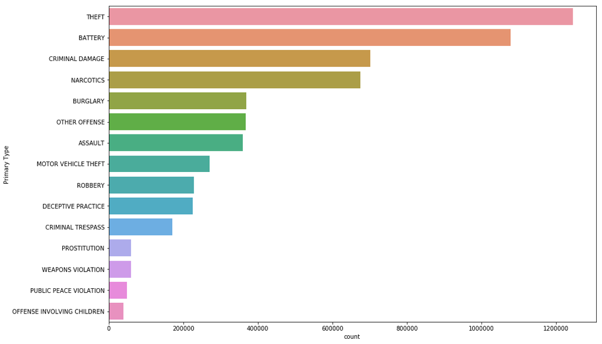

```python
plt.figure(figsize = (15, 10))
sns.countplot(y= 'Primary Type', data = chicago_df, order = chicago_df['Primary Type'].value_counts().iloc[:15].index)
```

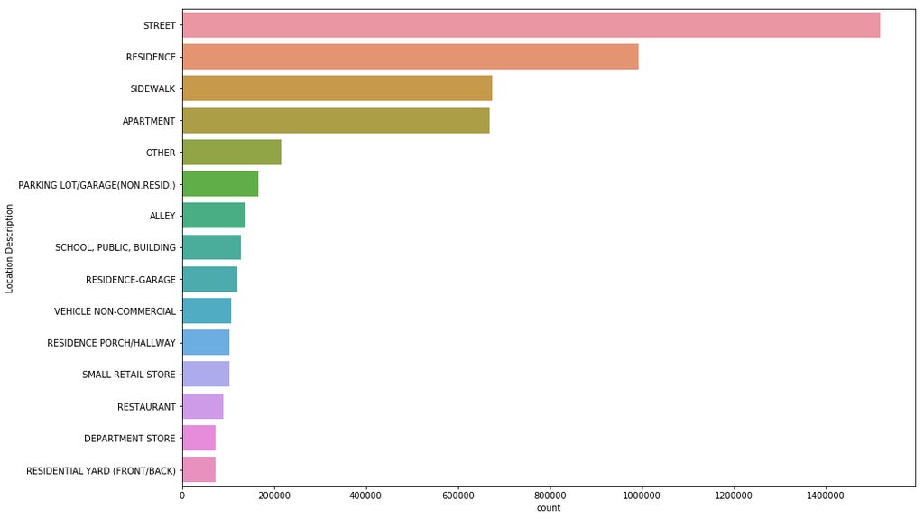

```python
plt.figure(figsize = (15, 10))
sns.countplot(y= 'Location Description', data = chicago_df, order = chicago_df['Location Description'].value_counts().iloc[:15].index)
```

```python
chicago_df.resample('Y').size()
```

```
Date
2005-12-31    455811
2006-12-31    794684
2007-12-31    621848
2008-12-31    852053
2009-12-31    783900
2010-12-31    700691
2011-12-31    352066
2012-12-31    335670
2013-12-31    306703
2014-12-31    274527
2015-12-31    262995
2016-12-31    265462
2017-12-31     11357
Freq: A-DEC, dtype: int64
```

```
Text(0,0.5,'Number of Crimes')
```

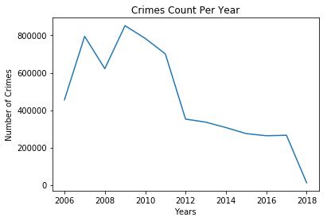

```python
# Resample is a Convenience method for frequency conversion and resampling of time series.

plt.plot(chicago_df.resample('Y').size())
plt.title('Crimes Count Per Year')
plt.xlabel('Years')
plt.ylabel('Number of Crimes')
```

```python
chicago_df.resample('M').size()
```

```
Date
2005-01-31    33983
2005-02-28    32042
2005-03-31    36970
2005-04-30    38963
2005-05-31    40572
2005-06-30    40234
2005-07-31    41976
2005-08-31    41741
2005-09-30    39833
2005-10-31    40204
2005-11-30    36244
2005-12-31    33049
2006-01-31    37605
2006-02-28    34063
2006-03-31    43721
2006-04-30    69128
2006-05-31    79013
2006-06-30    77348
2006-07-31    82750
2006-08-31    80628
2006-09-30    75045
2006-10-31    76870
2006-11-30    70710
2006-12-31    67803
2007-01-31    67123
2007-02-28    53811
2007-03-31    71857
2007-04-30    70389
2007-05-31    78170
2007-06-30    55802
              ...
2014-08-31    25802
2014-09-30    23811
2014-10-31    23911
2014-11-30    20680
2014-12-31    20891
2015-01-31    20656
2015-02-28    16287
2015-03-31    21560
```

[output cut: 8 more lines]

```
2015-12-31    21006
2016-01-31    20375
2016-02-29    18590
2016-03-31    21878
2016-04-30    20962
2016-05-31    23332
2016-06-30    23791
2016-07-31    24646
2016-08-31    24619
2016-09-30    23235
2016-10-31    23314
2016-11-30    21140
2016-12-31    19580
2017-01-31    11357
Freq: M, Length: 145, dtype: int64
```

```
Text(0,0.5,'Number of Crimes')
```

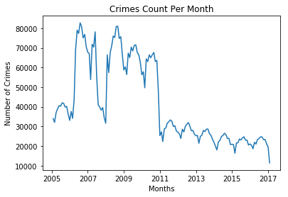

```python
# Resample is a Convenience method for frequency conversion and resampling of time series.

plt.plot(chicago_df.resample('M').size())
plt.title('Crimes Count Per Month')
plt.xlabel('Months')
plt.ylabel('Number of Crimes')
```

```python
chicago_df.resample('Q').size()
```

```
Date
2005-03-31    102995
2005-06-30    119769
2005-09-30    123550
2005-12-31    109497
2006-03-31    115389
2006-06-30    225489
2006-09-30    238423
2006-12-31    215383
2007-03-31    192791
2007-06-30    204361
2007-09-30    119086
2007-12-31    105610
2008-03-31    191523
2008-06-30    222331
2008-09-30    236695
2008-12-31    201504
2009-03-31    184055
2009-06-30    203916
2009-09-30    210446
2009-12-31    185483
2010-03-31    171848
2010-06-30    194453
2010-09-30    197116
2010-12-31    137274
2011-03-31     78167
2011-06-30     93064
2011-09-30     95835
2011-12-31     85000
2012-03-31     78574
2012-06-30     88283
2012-09-30     89685
2012-12-31     79128
2013-03-31     71651
2013-06-30     80776
2013-09-30     83510
2013-12-31     70766
2014-03-31     59964
2014-06-30     72991
2014-09-30     76090
2014-12-31     65482
2015-03-31     58503
2015-06-30     68239
2015-09-30     71782
2015-12-31     64471
2016-03-31     60843
2016-06-30     68085
2016-09-30     72500
2016-12-31     64034
2017-03-31     11357
Freq: Q-DEC, dtype: int64
```

```
Text(0,0.5,'Number of Crimes')
```

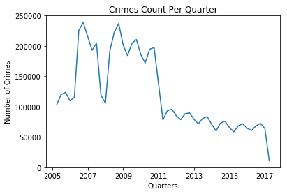

```python
# Resample is a Convenience method for frequency conversion and resampling of time series.

plt.plot(chicago_df.resample('Q').size())
plt.title('Crimes Count Per Quarter')
plt.xlabel('Quarters')
plt.ylabel('Number of Crimes')
```

# STEP #3: PREPARING THE DATA

```python
chicago_prophet = chicago_df.resample('M').size().reset_index()
```

```python
chicago_prophet
```

|  | Date | 0 |
| --- | --- | --- |
| 0 | 2005-01-31 | 33983 |
| 1 | 2005-02-28 | 32042 |
| 2 | 2005-03-31 | 36970 |
| 3 | 2005-04-30 | 38963 |
| 4 | 2005-05-31 | 40572 |
| 5 | 2005-06-30 | 40234 |
| 6 | 2005-07-31 | 41976 |
| 7 | 2005-08-31 | 41741 |
| 8 | 2005-09-30 | 39833 |
| 9 | 2005-10-31 | 40204 |
| 10 | 2005-11-30 | 36244 |
| 11 | 2005-12-31 | 33049 |
| 12 | 2006-01-31 | 37605 |
| 13 | 2006-02-28 | 34063 |
| 14 | 2006-03-31 | 43721 |
| 15 | 2006-04-30 | 69128 |
| 16 | 2006-05-31 | 79013 |
| 17 | 2006-06-30 | 77348 |
| 18 | 2006-07-31 | 82750 |
| 19 | 2006-08-31 | 80628 |
| 20 | 2006-09-30 | 75045 |
| 21 | 2006-10-31 | 76870 |
| 22 | 2006-11-30 | 70710 |
| 23 | 2006-12-31 | 67803 |
| 24 | 2007-01-31 | 67123 |
| 25 | 2007-02-28 | 53811 |
| 26 | 2007-03-31 | 71857 |
| 27 | 2007-04-30 | 70389 |
| 28 | 2007-05-31 | 78170 |
| 29 | 2007-06-30 | 55802 |
| ... | ... | ... |
| 115 | 2014-08-31 | 25802 |
| 116 | 2014-09-30 | 23811 |
| 117 | 2014-10-31 | 23911 |
| 118 | 2014-11-30 | 20680 |
| 119 | 2014-12-31 | 20891 |
| 120 | 2015-01-31 | 20656 |
| 121 | 2015-02-28 | 16287 |
| 122 | 2015-03-31 | 21560 |
| 123 | 2015-04-30 | 21610 |
| 124 | 2015-05-31 | 23570 |
| 125 | 2015-06-30 | 23059 |
| 126 | 2015-07-31 | 24101 |
| 127 | 2015-08-31 | 24685 |
| 128 | 2015-09-30 | 22996 |
| 129 | 2015-10-31 | 22979 |
| 130 | 2015-11-30 | 20486 |
| 131 | 2015-12-31 | 21006 |
| 132 | 2016-01-31 | 20375 |
| 133 | 2016-02-29 | 18590 |
| 134 | 2016-03-31 | 21878 |
| 135 | 2016-04-30 | 20962 |
| 136 | 2016-05-31 | 23332 |
| 137 | 2016-06-30 | 23791 |
| 138 | 2016-07-31 | 24646 |
| 139 | 2016-08-31 | 24619 |
| 140 | 2016-09-30 | 23235 |
| 141 | 2016-10-31 | 23314 |
| 142 | 2016-11-30 | 21140 |
| 143 | 2016-12-31 | 19580 |
| 144 | 2017-01-31 | 11357 |

145 rows × 2 columns

```python
chicago_prophet.columns = ['Date', 'Crime Count']
```

```python
chicago_prophet
```

|  | Date | Crime Count |
| --- | --- | --- |
| 0 | 2005-01-31 | 33983 |
| 1 | 2005-02-28 | 32042 |
| 2 | 2005-03-31 | 36970 |
| 3 | 2005-04-30 | 38963 |
| 4 | 2005-05-31 | 40572 |
| 5 | 2005-06-30 | 40234 |
| 6 | 2005-07-31 | 41976 |
| 7 | 2005-08-31 | 41741 |
| 8 | 2005-09-30 | 39833 |
| 9 | 2005-10-31 | 40204 |
| 10 | 2005-11-30 | 36244 |
| 11 | 2005-12-31 | 33049 |
| 12 | 2006-01-31 | 37605 |
| 13 | 2006-02-28 | 34063 |
| 14 | 2006-03-31 | 43721 |
| 15 | 2006-04-30 | 69128 |
| 16 | 2006-05-31 | 79013 |
| 17 | 2006-06-30 | 77348 |
| 18 | 2006-07-31 | 82750 |
| 19 | 2006-08-31 | 80628 |
| 20 | 2006-09-30 | 75045 |
| 21 | 2006-10-31 | 76870 |
| 22 | 2006-11-30 | 70710 |
| 23 | 2006-12-31 | 67803 |
| 24 | 2007-01-31 | 67123 |
| 25 | 2007-02-28 | 53811 |
| 26 | 2007-03-31 | 71857 |
| 27 | 2007-04-30 | 70389 |
| 28 | 2007-05-31 | 78170 |
| 29 | 2007-06-30 | 55802 |
| ... | ... | ... |
| 115 | 2014-08-31 | 25802 |
| 116 | 2014-09-30 | 23811 |
| 117 | 2014-10-31 | 23911 |
| 118 | 2014-11-30 | 20680 |
| 119 | 2014-12-31 | 20891 |
| 120 | 2015-01-31 | 20656 |
| 121 | 2015-02-28 | 16287 |
| 122 | 2015-03-31 | 21560 |
| 123 | 2015-04-30 | 21610 |
| 124 | 2015-05-31 | 23570 |
| 125 | 2015-06-30 | 23059 |
| 126 | 2015-07-31 | 24101 |
| 127 | 2015-08-31 | 24685 |
| 128 | 2015-09-30 | 22996 |
| 129 | 2015-10-31 | 22979 |
| 130 | 2015-11-30 | 20486 |
| 131 | 2015-12-31 | 21006 |
| 132 | 2016-01-31 | 20375 |
| 133 | 2016-02-29 | 18590 |
| 134 | 2016-03-31 | 21878 |
| 135 | 2016-04-30 | 20962 |
| 136 | 2016-05-31 | 23332 |
| 137 | 2016-06-30 | 23791 |
| 138 | 2016-07-31 | 24646 |
| 139 | 2016-08-31 | 24619 |
| 140 | 2016-09-30 | 23235 |
| 141 | 2016-10-31 | 23314 |
| 142 | 2016-11-30 | 21140 |
| 143 | 2016-12-31 | 19580 |
| 144 | 2017-01-31 | 11357 |

145 rows × 2 columns

```python
chicago_prophet_df = pd.DataFrame(chicago_prophet)
```

```python
chicago_prophet_df
```

|  | Date | Crime Count |
| --- | --- | --- |
| 0 | 2005-01-31 | 33983 |
| 1 | 2005-02-28 | 32042 |
| 2 | 2005-03-31 | 36970 |
| 3 | 2005-04-30 | 38963 |
| 4 | 2005-05-31 | 40572 |
| 5 | 2005-06-30 | 40234 |
| 6 | 2005-07-31 | 41976 |
| 7 | 2005-08-31 | 41741 |
| 8 | 2005-09-30 | 39833 |
| 9 | 2005-10-31 | 40204 |
| 10 | 2005-11-30 | 36244 |
| 11 | 2005-12-31 | 33049 |
| 12 | 2006-01-31 | 37605 |
| 13 | 2006-02-28 | 34063 |
| 14 | 2006-03-31 | 43721 |
| 15 | 2006-04-30 | 69128 |
| 16 | 2006-05-31 | 79013 |
| 17 | 2006-06-30 | 77348 |
| 18 | 2006-07-31 | 82750 |
| 19 | 2006-08-31 | 80628 |
| 20 | 2006-09-30 | 75045 |
| 21 | 2006-10-31 | 76870 |
| 22 | 2006-11-30 | 70710 |
| 23 | 2006-12-31 | 67803 |
| 24 | 2007-01-31 | 67123 |
| 25 | 2007-02-28 | 53811 |
| 26 | 2007-03-31 | 71857 |
| 27 | 2007-04-30 | 70389 |
| 28 | 2007-05-31 | 78170 |
| 29 | 2007-06-30 | 55802 |
| ... | ... | ... |
| 115 | 2014-08-31 | 25802 |
| 116 | 2014-09-30 | 23811 |
| 117 | 2014-10-31 | 23911 |
| 118 | 2014-11-30 | 20680 |
| 119 | 2014-12-31 | 20891 |
| 120 | 2015-01-31 | 20656 |
| 121 | 2015-02-28 | 16287 |
| 122 | 2015-03-31 | 21560 |
| 123 | 2015-04-30 | 21610 |
| 124 | 2015-05-31 | 23570 |
| 125 | 2015-06-30 | 23059 |
| 126 | 2015-07-31 | 24101 |
| 127 | 2015-08-31 | 24685 |
| 128 | 2015-09-30 | 22996 |
| 129 | 2015-10-31 | 22979 |
| 130 | 2015-11-30 | 20486 |
| 131 | 2015-12-31 | 21006 |
| 132 | 2016-01-31 | 20375 |
| 133 | 2016-02-29 | 18590 |
| 134 | 2016-03-31 | 21878 |
| 135 | 2016-04-30 | 20962 |
| 136 | 2016-05-31 | 23332 |
| 137 | 2016-06-30 | 23791 |
| 138 | 2016-07-31 | 24646 |
| 139 | 2016-08-31 | 24619 |
| 140 | 2016-09-30 | 23235 |
| 141 | 2016-10-31 | 23314 |
| 142 | 2016-11-30 | 21140 |
| 143 | 2016-12-31 | 19580 |
| 144 | 2017-01-31 | 11357 |

145 rows × 2 columns

# STEP #4: MAKE PREDICTIONS

```python
chicago_prophet_df.columns
```

```
Index(['Date', 'Crime Count'], dtype='object')
```

```python
chicago_prophet_df_final = chicago_prophet_df.rename(columns={'Date':'ds', 'Crime Count':'y'})
```

```python
chicago_prophet_df_final
```

|  | ds | y |
| --- | --- | --- |
| 0 | 2005-01-31 | 33983 |
| 1 | 2005-02-28 | 32042 |
| 2 | 2005-03-31 | 36970 |
| 3 | 2005-04-30 | 38963 |
| 4 | 2005-05-31 | 40572 |
| 5 | 2005-06-30 | 40234 |
| 6 | 2005-07-31 | 41976 |
| 7 | 2005-08-31 | 41741 |
| 8 | 2005-09-30 | 39833 |
| 9 | 2005-10-31 | 40204 |
| 10 | 2005-11-30 | 36244 |
| 11 | 2005-12-31 | 33049 |
| 12 | 2006-01-31 | 37605 |
| 13 | 2006-02-28 | 34063 |
| 14 | 2006-03-31 | 43721 |
| 15 | 2006-04-30 | 69128 |
| 16 | 2006-05-31 | 79013 |
| 17 | 2006-06-30 | 77348 |
| 18 | 2006-07-31 | 82750 |
| 19 | 2006-08-31 | 80628 |
| 20 | 2006-09-30 | 75045 |
| 21 | 2006-10-31 | 76870 |
| 22 | 2006-11-30 | 70710 |
| 23 | 2006-12-31 | 67803 |
| 24 | 2007-01-31 | 67123 |
| 25 | 2007-02-28 | 53811 |
| 26 | 2007-03-31 | 71857 |
| 27 | 2007-04-30 | 70389 |
| 28 | 2007-05-31 | 78170 |
| 29 | 2007-06-30 | 55802 |
| ... | ... | ... |
| 115 | 2014-08-31 | 25802 |
| 116 | 2014-09-30 | 23811 |
| 117 | 2014-10-31 | 23911 |
| 118 | 2014-11-30 | 20680 |
| 119 | 2014-12-31 | 20891 |
| 120 | 2015-01-31 | 20656 |
| 121 | 2015-02-28 | 16287 |
| 122 | 2015-03-31 | 21560 |
| 123 | 2015-04-30 | 21610 |
| 124 | 2015-05-31 | 23570 |
| 125 | 2015-06-30 | 23059 |
| 126 | 2015-07-31 | 24101 |
| 127 | 2015-08-31 | 24685 |
| 128 | 2015-09-30 | 22996 |
| 129 | 2015-10-31 | 22979 |
| 130 | 2015-11-30 | 20486 |
| 131 | 2015-12-31 | 21006 |
| 132 | 2016-01-31 | 20375 |
| 133 | 2016-02-29 | 18590 |
| 134 | 2016-03-31 | 21878 |
| 135 | 2016-04-30 | 20962 |
| 136 | 2016-05-31 | 23332 |
| 137 | 2016-06-30 | 23791 |
| 138 | 2016-07-31 | 24646 |
| 139 | 2016-08-31 | 24619 |
| 140 | 2016-09-30 | 23235 |
| 141 | 2016-10-31 | 23314 |
| 142 | 2016-11-30 | 21140 |
| 143 | 2016-12-31 | 19580 |
| 144 | 2017-01-31 | 11357 |

145 rows × 2 columns

```python
m = Prophet()
m.fit(chicago_prophet_df_final)
```

[output not shown]

```
<fbprophet.forecaster.Prophet at 0x15e51555208>
```

```python
# Forcasting into the future
future = m.make_future_dataframe(periods=365)
forecast = m.predict(future)
```

```python
forecast
```

|  | ds | trend | yhat_lower | yhat_upper | trend_lower | trend_upper | additive_terms | additive_terms_lower | additive_terms_upper | yearly | yearly_lower | yearly_upper | multiplicative_terms | multiplicative_terms_lower | multiplicative_terms_upper | yhat |
| --- | --- | --- | --- | --- | --- | --- | --- | --- | --- | --- | --- | --- | --- | --- | --- | --- |
| 0 | 2005-01-31 | 60454.550849 | 38579.873129 | 72458.344880 | 60454.550849 | 60454.550849 | -4762.896867 | -4762.896867 | -4762.896867 | -4762.896867 | -4762.896867 | -4762.896867 | 0.0 | 0.0 | 0.0 | 55691.653982 |
| 1 | 2005-02-28 | 60322.147047 | 34221.041714 | 67421.454566 | 60322.147047 | 60322.147047 | -9500.949898 | -9500.949898 | -9500.949898 | -9500.949898 | -9500.949898 | -9500.949898 | 0.0 | 0.0 | 0.0 | 50821.197149 |
| 2 | 2005-03-31 | 60175.557124 | 42823.370306 | 75698.921616 | 60175.557124 | 60175.557124 | -1224.296867 | -1224.296867 | -1224.296867 | -1224.296867 | -1224.296867 | -1224.296867 | 0.0 | 0.0 | 0.0 | 58951.260257 |
| 3 | 2005-04-30 | 60033.695908 | 44555.300811 | 79384.772219 | 60033.695908 | 60033.695908 | 1182.976012 | 1182.976012 | 1182.976012 | 1182.976012 | 1182.976012 | 1182.976012 | 0.0 | 0.0 | 0.0 | 61216.671919 |
| 4 | 2005-05-31 | 59887.105985 | 49410.229024 | 81613.777868 | 59887.105985 | 59887.105985 | 5498.632207 | 5498.632207 | 5498.632207 | 5498.632207 | 5498.632207 | 5498.632207 | 0.0 | 0.0 | 0.0 | 65385.738191 |
| 5 | 2005-06-30 | 59745.244769 | 47098.245873 | 78678.030782 | 59745.244769 | 59745.244769 | 3577.501610 | 3577.501610 | 3577.501610 | 3577.501610 | 3577.501610 | 3577.501610 | 0.0 | 0.0 | 0.0 | 63322.746379 |
| 6 | 2005-07-31 | 59598.654838 | 47806.382068 | 80665.905762 | 59598.654838 | 59598.654838 | 4583.361194 | 4583.361194 | 4583.361194 | 4583.361194 | 4583.361194 | 4583.361194 | 0.0 | 0.0 | 0.0 | 64182.016032 |
| 7 | 2005-08-31 | 59452.064908 | 47368.296071 | 80756.033012 | 59452.064908 | 59452.064908 | 4499.375562 | 4499.375562 | 4499.375562 | 4499.375562 | 4499.375562 | 4499.375562 | 0.0 | 0.0 | 0.0 | 63951.440470 |
| 8 | 2005-09-30 | 59310.203685 | 44535.626188 | 77006.014932 | 59310.203685 | 59310.203685 | 1749.549105 | 1749.549105 | 1749.549105 | 1749.549105 | 1749.549105 | 1749.549105 | 0.0 | 0.0 | 0.0 | 61059.752790 |
| 9 | 2005-10-31 | 59163.613755 | 45431.878281 | 78473.609767 | 59163.613755 | 59163.613755 | 2397.346677 | 2397.346677 | 2397.346677 | 2397.346677 | 2397.346677 | 2397.346677 | 0.0 | 0.0 | 0.0 | 61560.960432 |
| 10 | 2005-11-30 | 59021.752529 | 39855.843322 | 73045.342043 | 59021.752529 | 59021.752529 | -2065.033670 | -2065.033670 | -2065.033670 | -2065.033670 | -2065.033670 | -2065.033670 | 0.0 | 0.0 | 0.0 | 56956.718858 |
| 11 | 2005-12-31 | 58875.162595 | 35993.544575 | 71131.998977 | 58875.162595 | 58875.162595 | -5992.119657 | -5992.119657 | -5992.119657 | -5992.119657 | -5992.119657 | -5992.119657 | 0.0 | 0.0 | 0.0 | 52883.042938 |
| 12 | 2006-01-31 | 58728.572661 | 36668.886036 | 70839.471318 | 58728.572661 | 58728.572661 | -4772.659269 | -4772.659269 | -4772.659269 | -4772.659269 | -4772.659269 | -4772.659269 | 0.0 | 0.0 | 0.0 | 53955.913392 |
| 13 | 2006-02-28 | 58596.168850 | 32430.561382 | 65806.466898 | 58596.168850 | 58596.168850 | -9503.051717 | -9503.051717 | -9503.051717 | -9503.051717 | -9503.051717 | -9503.051717 | 0.0 | 0.0 | 0.0 | 49093.117133 |
| 14 | 2006-03-31 | 58449.578916 | 39193.541836 | 71919.946197 | 58449.578916 | 58449.578916 | -1224.434198 | -1224.434198 | -1224.434198 | -1224.434198 | -1224.434198 | -1224.434198 | 0.0 | 0.0 | 0.0 | 57225.144718 |
| 15 | 2006-04-30 | 58307.717686 | 42625.987661 | 77057.400277 | 58307.717686 | 58307.717686 | 1187.100547 | 1187.100547 | 1187.100547 | 1187.100547 | 1187.100547 | 1187.100547 | 0.0 | 0.0 | 0.0 | 59494.818233 |
| 16 | 2006-05-31 | 58161.127748 | 45990.584105 | 80277.571713 | 58161.127748 | 58161.127748 | 5451.418874 | 5451.418874 | 5451.418874 | 5451.418874 | 5451.418874 | 5451.418874 | 0.0 | 0.0 | 0.0 | 63612.546621 |
| 17 | 2006-06-30 | 58019.266517 | 45778.759963 | 79069.169730 | 58019.266517 | 58019.266517 | 3564.138248 | 3564.138248 | 3564.138248 | 3564.138248 | 3564.138248 | 3564.138248 | 0.0 | 0.0 | 0.0 | 61583.404765 |
| 18 | 2006-07-31 | 57872.676579 | 47002.201998 | 79782.570772 | 57872.676579 | 57872.676579 | 4563.254349 | 4563.254349 | 4563.254349 | 4563.254349 | 4563.254349 | 4563.254349 | 0.0 | 0.0 | 0.0 | 62435.930927 |
| 19 | 2006-08-31 | 57726.086594 | 45447.102442 | 79160.703585 | 57726.086594 | 57726.086594 | 4479.990711 | 4479.990711 | 4479.990711 | 4479.990711 | 4479.990711 | 4479.990711 | 0.0 | 0.0 | 0.0 | 62206.077306 |
| 20 | 2006-09-30 | 57584.225319 | 41994.861861 | 76377.523816 | 57584.225319 | 57584.225319 | 1829.842795 | 1829.842795 | 1829.842795 | 1829.842795 | 1829.842795 | 1829.842795 | 0.0 | 0.0 | 0.0 | 59414.068114 |
| 21 | 2006-10-31 | 57437.635335 | 43300.623636 | 77873.098798 | 57437.635335 | 57437.635335 | 2439.830765 | 2439.830765 | 2439.830765 | 2439.830765 | 2439.830765 | 2439.830765 | 0.0 | 0.0 | 0.0 | 59877.466100 |
| 22 | 2006-11-30 | 57295.774060 | 38210.477095 | 73388.386714 | 57295.774060 | 57295.774060 | -2045.360906 | -2045.360906 | -2045.360906 | -2045.360906 | -2045.360906 | -2045.360906 | 0.0 | 0.0 | 0.0 | 55250.413154 |
| 23 | 2006-12-31 | 57149.184075 | 34675.761615 | 67310.501555 | 57149.184075 | 57149.184075 | -6013.413267 | -6013.413267 | -6013.413267 | -6013.413267 | -6013.413267 | -6013.413267 | 0.0 | 0.0 | 0.0 | 51135.770808 |
| 24 | 2007-01-31 | 56994.480254 | 35873.268789 | 69294.200682 | 56994.480254 | 56994.480254 | -4783.036614 | -4783.036614 | -4783.036614 | -4783.036614 | -4783.036614 | -4783.036614 | 0.0 | 0.0 | 0.0 | 52211.443640 |
| 25 | 2007-02-28 | 56854.747771 | 29801.353956 | 62906.688914 | 56854.747771 | 56854.747771 | -9501.921423 | -9501.921423 | -9501.921423 | -9501.921423 | -9501.921423 | -9501.921423 | 0.0 | 0.0 | 0.0 | 47352.826348 |
| 26 | 2007-03-31 | 56700.043950 | 38154.033064 | 72707.777440 | 56700.043950 | 56700.043950 | -1225.266871 | -1225.266871 | -1225.266871 | -1225.266871 | -1225.266871 | -1225.266871 | 0.0 | 0.0 | 0.0 | 55474.777078 |
| 27 | 2007-04-30 | 56550.330574 | 40491.474353 | 74706.900200 | 56550.330574 | 56550.330574 | 1190.223261 | 1190.223261 | 1190.223261 | 1190.223261 | 1190.223261 | 1190.223261 | 0.0 | 0.0 | 0.0 | 57740.553835 |
| 28 | 2007-05-31 | 56395.626753 | 45020.807451 | 77993.605388 | 56395.626753 | 56395.626753 | 5402.206493 | 5402.206493 | 5402.206493 | 5402.206493 | 5402.206493 | 5402.206493 | 0.0 | 0.0 | 0.0 | 61797.833246 |
| 29 | 2007-06-30 | 56230.582698 | 43009.450294 | 77307.962960 | 56230.582698 | 56230.582698 | 3551.457755 | 3551.457755 | 3551.457755 | 3551.457755 | 3551.457755 | 3551.457755 | 0.0 | 0.0 | 0.0 | 59782.040452 |
| ... | ... | ... | ... | ... | ... | ... | ... | ... | ... | ... | ... | ... | ... | ... | ... | ... |
| 480 | 2018-01-02 | 10430.753220 | -10645.820107 | 20038.001128 | 10287.038125 | 10556.745840 | -5814.639079 | -5814.639079 | -5814.639079 | -5814.639079 | -5814.639079 | -5814.639079 | 0.0 | 0.0 | 0.0 | 4616.114140 |
| 481 | 2018-01-03 | 10417.686680 | -12131.618633 | 21312.023151 | 10273.332005 | 10544.184093 | -5725.854616 | -5725.854616 | -5725.854616 | -5725.854616 | -5725.854616 | -5725.854616 | 0.0 | 0.0 | 0.0 | 4691.832063 |
| 482 | 2018-01-04 | 10404.620140 | -11264.733448 | 21481.058839 | 10259.615204 | 10531.622345 | -5640.534387 | -5640.534387 | -5640.534387 | -5640.534387 | -5640.534387 | -5640.534387 | 0.0 | 0.0 | 0.0 | 4764.085753 |
| 483 | 2018-01-05 | 10391.553601 | -11293.427706 | 21583.702828 | 10245.910236 | 10519.060598 | -5560.875533 | -5560.875533 | -5560.875533 | -5560.875533 | -5560.875533 | -5560.875533 | 0.0 | 0.0 | 0.0 | 4830.678068 |
| 484 | 2018-01-06 | 10378.487061 | -10571.821161 | 21827.517378 | 10232.514272 | 10506.498851 | -5488.665623 | -5488.665623 | -5488.665623 | -5488.665623 | -5488.665623 | -5488.665623 | 0.0 | 0.0 | 0.0 | 4889.821439 |
| 485 | 2018-01-07 | 10365.420522 | -11213.789750 | 21737.667858 | 10218.899641 | 10493.937103 | -5425.240870 | -5425.240870 | -5425.240870 | -5425.240870 | -5425.240870 | -5425.240870 | 0.0 | 0.0 | 0.0 | 4940.179652 |
| 486 | 2018-01-08 | 10352.353982 | -11068.421737 | 22756.628202 | 10205.056042 | 10481.449293 | -5371.460788 | -5371.460788 | -5371.460788 | -5371.460788 | -5371.460788 | -5371.460788 | 0.0 | 0.0 | 0.0 | 4980.893194 |
| 487 | 2018-01-09 | 10339.287442 | -11751.596928 | 22353.659111 | 10191.219798 | 10469.065920 | -5327.699997 | -5327.699997 | -5327.699997 | -5327.699997 | -5327.699997 | -5327.699997 | 0.0 | 0.0 | 0.0 | 5011.587446 |
| 488 | 2018-01-10 | 10326.220903 | -12214.265224 | 21555.904799 | 10177.503749 | 10456.812418 | -5293.857323 | -5293.857323 | -5293.857323 | -5293.857323 | -5293.857323 | -5293.857323 | 0.0 | 0.0 | 0.0 | 5032.363580 |
| 489 | 2018-01-11 | 10313.154363 | -13379.641545 | 21442.105207 | 10163.873381 | 10444.834064 | -5269.381789 | -5269.381789 | -5269.381789 | -5269.381789 | -5269.381789 | -5269.381789 | 0.0 | 0.0 | 0.0 | 5043.772575 |
| 490 | 2018-01-12 | 10300.087824 | -11407.652737 | 22014.507343 | 10150.269457 | 10432.577518 | -5253.314515 | -5253.314515 | -5253.314515 | -5253.314515 | -5253.314515 | -5253.314515 | 0.0 | 0.0 | 0.0 | 5046.773309 |
| 491 | 2018-01-13 | 10287.021284 | -11767.060141 | 23105.051714 | 10136.676775 | 10420.474065 | -5244.345070 | -5244.345070 | -5244.345070 | -5244.345070 | -5244.345070 | -5244.345070 | 0.0 | 0.0 | 0.0 | 5042.676214 |
| 492 | 2018-01-14 | 10273.954744 | -12453.383825 | 22490.477042 | 10122.988290 | 10408.031781 | -5240.880304 | -5240.880304 | -5240.880304 | -5240.880304 | -5240.880304 | -5240.880304 | 0.0 | 0.0 | 0.0 | 5033.074441 |
| 493 | 2018-01-15 | 10260.888205 | -11792.410668 | 21383.620828 | 10109.359927 | 10395.589498 | -5241.123306 | -5241.123306 | -5241.123306 | -5241.123306 | -5241.123306 | -5241.123306 | 0.0 | 0.0 | 0.0 | 5019.764899 |
| 494 | 2018-01-16 | 10247.821665 | -10884.794995 | 21807.204144 | 10095.446589 | 10383.147214 | -5243.159787 | -5243.159787 | -5243.159787 | -5243.159787 | -5243.159787 | -5243.159787 | 0.0 | 0.0 | 0.0 | 5004.661878 |
| 495 | 2018-01-17 | 10234.755126 | -11117.490200 | 21908.112254 | 10081.328118 | 10370.704930 | -5245.048924 | -5245.048924 | -5245.048924 | -5245.048924 | -5245.048924 | -5245.048924 | 0.0 | 0.0 | 0.0 | 4989.706201 |
| 496 | 2018-01-18 | 10221.688586 | -11471.233652 | 22612.102358 | 10067.579986 | 10358.232019 | -5244.915571 | -5244.915571 | -5244.915571 | -5244.915571 | -5244.915571 | -5244.915571 | 0.0 | 0.0 | 0.0 | 4976.773015 |
| 497 | 2018-01-19 | 10208.622046 | -12616.078056 | 22604.293475 | 10053.863185 | 10345.699704 | -5241.040633 | -5241.040633 | -5241.040633 | -5241.040633 | -5241.040633 | -5241.040633 | 0.0 | 0.0 | 0.0 | 4967.581413 |
| 498 | 2018-01-20 | 10195.555507 | -11085.109200 | 21862.639163 | 10040.146384 | 10333.148577 | -5231.946498 | -5231.946498 | -5231.946498 | -5231.946498 | -5231.946498 | -5231.946498 | 0.0 | 0.0 | 0.0 | 4963.609009 |
| 499 | 2018-01-21 | 10182.488967 | -12116.756382 | 22124.561839 | 10026.429583 | 10320.597449 | -5216.474494 | -5216.474494 | -5216.474494 | -5216.474494 | -5216.474494 | -5216.474494 | 0.0 | 0.0 | 0.0 | 4966.014473 |
| 500 | 2018-01-22 | 10169.422428 | -11799.236660 | 22128.247318 | 10012.712782 | 10308.046322 | -5193.851637 | -5193.851637 | -5193.851637 | -5193.851637 | -5193.851637 | -5193.851637 | 0.0 | 0.0 | 0.0 | 4975.570791 |
| 501 | 2018-01-23 | 10156.355888 | -11397.718675 | 21488.804694 | 9998.995980 | 10295.688169 | -5163.744193 | -5163.744193 | -5163.744193 | -5163.744193 | -5163.744193 | -5163.744193 | 0.0 | 0.0 | 0.0 | 4992.611695 |
| 502 | 2018-01-24 | 10143.289348 | -12170.143585 | 21137.408443 | 9985.289993 | 10283.354063 | -5126.296039 | -5126.296039 | -5126.296039 | -5126.296039 | -5126.296039 | -5126.296039 | 0.0 | 0.0 | 0.0 | 5016.993309 |
| 503 | 2018-01-25 | 10130.222809 | -11855.103144 | 21615.603916 | 9971.447744 | 10271.019957 | -5082.150230 | -5082.150230 | -5082.150230 | -5082.150230 | -5082.150230 | -5082.150230 | 0.0 | 0.0 | 0.0 | 5048.072579 |
| 504 | 2018-01-26 | 10117.156269 | -12025.376518 | 22220.684386 | 9957.493001 | 10258.685851 | -5032.452727 | -5032.452727 | -5032.452727 | -5032.452727 | -5032.452727 | -5032.452727 | 0.0 | 0.0 | 0.0 | 5084.703542 |
| 505 | 2018-01-27 | 10104.089730 | -12326.781502 | 21628.736366 | 9943.939751 | 10246.351744 | -4978.837801 | -4978.837801 | -4978.837801 | -4978.837801 | -4978.837801 | -4978.837801 | 0.0 | 0.0 | 0.0 | 5125.251929 |
| 506 | 2018-01-28 | 10091.023190 | -12000.100061 | 22722.886587 | 9930.400801 | 10234.017638 | -4923.395183 | -4923.395183 | -4923.395183 | -4923.395183 | -4923.395183 | -4923.395183 | 0.0 | 0.0 | 0.0 | 5167.628007 |
| 507 | 2018-01-29 | 10077.956651 | -11021.460045 | 21882.372752 | 9916.765027 | 10221.727326 | -4868.619657 | -4868.619657 | -4868.619657 | -4868.619657 | -4868.619657 | -4868.619657 | 0.0 | 0.0 | 0.0 | 5209.336993 |
| 508 | 2018-01-30 | 10064.890111 | -11496.619265 | 20772.074491 | 9903.067605 | 10209.526120 | -4817.344316 | -4817.344316 | -4817.344316 | -4817.344316 | -4817.344316 | -4817.344316 | 0.0 | 0.0 | 0.0 | 5247.545795 |
| 509 | 2018-01-31 | 10051.823571 | -13360.948215 | 21954.650132 | 9889.370183 | 10197.222692 | -4772.659269 | -4772.659269 | -4772.659269 | -4772.659269 | -4772.659269 | -4772.659269 | 0.0 | 0.0 | 0.0 | 5279.164302 |

510 rows × 16 columns

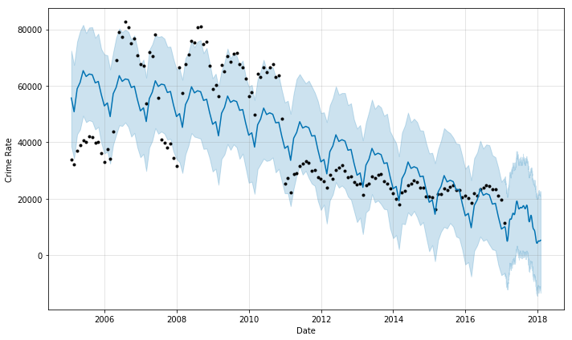

```python
figure = m.plot(forecast, xlabel='Date', ylabel='Crime Rate')
```

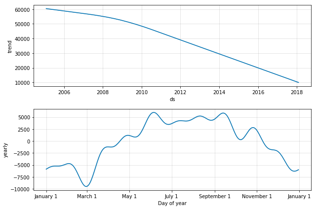

```python
figure3 = m.plot_components(forecast)
```